# Cyclistic - Market Insights Case Study

Aldrich Saladino

# Overview and Introduction

Cyclistic is a bike-share company based in Chicago that looks to revolutionize city mobility with a diverse range of bicycles in service. Different bike tyoes, such as reclining bikes, hand tricycles and carge bikes are also available to accomodate customer needs. The variation of bicycles available and service has gotten them to expand and grow up to 5,824 bicycles since launching in 2016.

### Purpose

This case study aims to dive into the usage of Cyclistic’s two primary user segments, casual riders and annual members. As a junior data analyst for Cyclistic on the Marketing team, we will identify and analyze trends on historical data surrounding trips on casual vs members. Understanding the distincions on usage is critical in planning and strategizing marketing campaigns that are effective. Using this data we can look to compare the differences between casual vs member, and the factors that determine why some users are casual and some are full members.

The goal is to find insights and data that can aid in the goal to converting casual members to full time members, and therefore increasing growth and market presence with increased profits.

### Business Task

The primary objective in this analysis is to explore and identify differing bike usages and patterns among our casual and annual members. By examining aspects of usage such as frequency, duration and preferred bike types, recommendations the strategy on customer conversion and digital market growth can be made.

## Data sources and preparation

The analysis uses historical bike trip data, spanning the previous 12 months from Cyclistic. The dataset, made by Motivate International Inc. provides comprehensive insights into the customer/user interactions along the bike-share system they’ve created.

This dataset includes information regarding metrics such as trip durations, bike types used and docking stations.

### Data Preparation Steps

1. Data Acquisition The data is downloaded as a monthly CSV, and downloaded from Motivate International Inc. which holds Cylcistic’s bike trip data
2. Data Organization Downloaded files are then organized and structured into a directory with separate subfolders. This is to delineate the raw and processed data upcoming
3. Initial data Processing through spreadsheets Additional columns such as ‘ride_length’ and ‘day_of_week’ were created as a standard across all CSV files. The aim is to enhance the dataset to get more detail in the analysis.
4. Data Cleaning Preliminary data cleaning involves seeking any values that are NA, or any missing values in columns within excel sheets. Further data cleaning is done within R to control what is being cleaned based on directed insight.

## Data Processing and Cleaning

This will go over the steps and actions taken to further clean and process data, in preparation for analysis and insights. This includes steps to process to import and process the initial dataframe as a base for further analysis.

### Tools and Approach

For processing and cleaning the Cyclistic bike-share data, Excel was used for a preliminary cleaning tool, due to it’s ease of use and simlicity while R was used for deeper cleaning due to it’s powerful manipulation capabilties and suitability for large dataset handling.

### Cleaning in Excel

1. Identify all missing values: This dataset had missing values within multiple various columns. This may be due in part to potential system errors in receiving usage history.
- To maintain as much data as possible, missing values that did not have a negative impact on finding our solution were kept (start_station_name, end_station_name). Information such as invalid ride_lengths due to ‘ended_at’ times being earlier then ‘started_at’ has been ommited as a system error, with negative ride_length values.
2. Formatting was done on new additional columns:
- To ensure consistency once these are uploaded into R, columns have been checked over with the appropriate datatype and format

### Cleaning and Processing R

Once the 12 excel CSV files have had an initial cleaning, further data manipulation/cleaning can be done within R. As mentioned R has powerful data manipulation capabilities, and is capable of handing large datasets like Cyclistics.

The first step is to place all cleaned CSV’s into a subfolders as the directory. This allows us to upload the CSV path in preparation for ingesting all 12 months worth of data.

### Confirm and prepare packages

Once we are ready to ingest and manipulate the data in R, the correct packages must be installed. The following packages are used in the cleaning and processing for analysis using the following code: * tidyverse * ggplot2 * dplyr * readr * janitor * skimr * scales

```r
packages <- c("dplyr", "ggplot2", "tidyr", "readr", "tidyverse", "janitor", "skimr", "scales", "DT")
for (package in packages) {
  if (!require(package, character.only = TRUE)) {
    install.packages(package)
    library(package, character.only = TRUE)
  }}
```

### Add the CSV files into R

Once packages have been installed and loaded, the data for Cyclistic can now be loaded in. These take in the form of CSV file, and are 12 month historical metrics ranging from Dec 2022 to Nov 2023.

Data will be imported using the read_csv function, and then combined together using bind_rows to make 1 datatable/ initial dataframe.

```r
df_2023_11  <- read_csv('/Users/aldrichsaladino/Desktop/vscode stuff/R Work/Cyclistic data/2023_11_divvy_tripdata.csv')
df_2023_10  <- read_csv('/Users/aldrichsaladino/Desktop/vscode stuff/R Work/Cyclistic data/2023_10_divvy_tripdata.csv')
df_2023_09  <- read_csv('/Users/aldrichsaladino/Desktop/vscode stuff/R Work/Cyclistic data/2023_09_divvy_tripdata.csv')
df_2023_08  <- read_csv('/Users/aldrichsaladino/Desktop/vscode stuff/R Work/Cyclistic data/2023_08_divvy_tripdata.csv')
df_2023_07  <- read_csv('/Users/aldrichsaladino/Desktop/vscode stuff/R Work/Cyclistic data/2023_07_divvy_tripdata.csv')
df_2023_06  <- read_csv('/Users/aldrichsaladino/Desktop/vscode stuff/R Work/Cyclistic data/2023_06_divvy_tripdata.csv')
df_2023_05  <- read_csv('/Users/aldrichsaladino/Desktop/vscode stuff/R Work/Cyclistic data/2023_05_divvy_tripdata.csv')
df_2023_04  <- read_csv('/Users/aldrichsaladino/Desktop/vscode stuff/R Work/Cyclistic data/2023_04_divvy_tripdata.csv')
df_2023_03  <- read_csv('/Users/aldrichsaladino/Desktop/vscode stuff/R Work/Cyclistic data/2023_03_divvy_tripdata.csv')
df_2023_02  <- read_csv('/Users/aldrichsaladino/Desktop/vscode stuff/R Work/Cyclistic data/2023_02_divvy_tripdata.csv')
df_2023_01  <- read_csv('/Users/aldrichsaladino/Desktop/vscode stuff/R Work/Cyclistic data/2023_01_divvy_tripdata.csv')
df_2022_12  <- read_csv('/Users/aldrichsaladino/Desktop/vscode stuff/R Work/Cyclistic data/2022_12_divvy_tripdata.csv')
```

Combining all notationed import data into one will allow us to work with 1 entire years worth of data together. Using the janitor package to help clean names and standardize the formatting within.

```r
df_combined_raw <- bind_rows(df_2023_11, df_2023_10, df_2023_09, df_2023_08, df_2023_07, df_2023_06, df_2023_05, df_2023_04, df_2023_03, df_2023_02, df_2023_01, df_2022_12)
df_combined <- clean_names(df_combined_raw)
```

## First intial check of the combined data

Prior to cleaning, understanding all columns and datatypes is useful to help understand what information is available and can be manipulated to gather insights. The ‘glimpse’ function shows this briefly so we can see columns applicable and their datatypes that we can work with

```r
glimpse(df_combined)
```

```
## Rows: 5,677,610
## Columns: 15
## $ ride_id            <chr> "4EAD8F1AD547356B", "6322270563BF5470", "B37BDE091E…
## $ rideable_type      <chr> "electric_bike", "electric_bike", "electric_bike", …
## $ started_at         <chr> "11/30/2023 21:50", "11/3/2023 9:44", "11/30/2023 1…
## $ ended_at           <chr> "11/30/2023 22:13", "11/3/2023 10:17", "11/30/2023 …
## $ start_station_name <chr> "Millennium Park", "Broadway & Sheridan Rd", "State…
## $ start_station_id   <chr> "13008", "13323", "TA1307000061", "TA1308000001", "…
## $ end_station_name   <chr> "Pine Grove Ave & Waveland Ave", "Broadway & Sherid…
## $ end_station_id     <chr> "TA1307000150", "13323", "TA1307000061", "TA1308000…
## $ start_lat          <dbl> 41.88110, 41.95287, 41.89753, 41.92628, 41.92628, 4…
## $ start_lng          <dbl> -87.62408, -87.65003, -87.62869, -87.63083, -87.630…
## $ end_lat            <dbl> 41.94947, 41.95283, 41.89745, 41.92628, 41.92628, 4…
## $ end_lng            <dbl> -87.64645, -87.64999, -87.62872, -87.63083, -87.630…
## $ member_casual      <chr> "member", "member", "member", "member", "member", "…
## $ ride_length        <time> 00:23:00, 00:33:00, 00:01:00, 00:26:00, 00:34:00, …
## $ day_of_week        <dbl> 5, 6, 5, 4, 6, 5, 5, 1, 1, 5, 1, 7, 1, 7, 6, 6, 5, …
```

## Cleaning Data

Within the historical data, there are some data with missing cells and line items. While unfortunate some data can still be used to aid in giving the most accurate insights possible and can be kept. In this situation there are 4 different types of insights we aim to gather to provide support to our problem: Usage Patterns, Popular Routes and Stations, Seasonality, Ride Lengths between the different demographics of members vs casual customers.

Any missing data under member_casual will need to be cleaned out, as it is not possible to determine which group the missing data belongs to. Furthermore day_of_week will be adjusted to mark down the exact day in words, rather than numbers for ease of understanding.

```r
day_names <- c("Sunday", "Monday", "Tuesday", "Wednesday", "Thursday", "Friday", "Saturday")

clean_df <- df_combined %>%
  filter(member_casual != "NA") %>%
  mutate(day_of_week = factor(day_names[day_of_week], levels = day_names)) %>%
  mutate(date_time_start = as.character(started_at)) %>%
  separate(date_time_start, into = c("start_date", "start_time"), sep = " ")
```

A final check once the cleaned dataframe has been made. This cleaned dataframe will serve as the base for other data manipulation endeavors.

```r
head(clean_df)
```

```
## # A tibble: 6 × 17
##   ride_id  rideable_type started_at ended_at start_station_name start_station_id
##   <chr>    <chr>         <chr>      <chr>    <chr>              <chr>
## 1 4EAD8F1… electric_bike 11/30/202… 11/30/2… Millennium Park    13008
## 2 6322270… electric_bike 11/3/2023… 11/3/20… Broadway & Sherid… 13323
## 3 B37BDE0… electric_bike 11/30/202… 11/30/2… State St & Pearso… TA1307000061
## 4 CF0CA5D… classic_bike  11/8/2023… 11/8/20… Theater on the La… TA1308000001
## 5 EB8381A… classic_bike  11/3/2023… 11/3/20… Theater on the La… TA1308000001
## 6 B8CF14E… electric_bike 11/30/202… 11/30/2… Pine Grove Ave & … TA1307000150
## # ℹ 11 more variables: end_station_name <chr>, end_station_id <chr>,
## #   start_lat <dbl>, start_lng <dbl>, end_lat <dbl>, end_lng <dbl>,
## #   member_casual <chr>, ride_length <time>, day_of_week <fct>,
## #   start_date <chr>, start_time <chr>
```

### Usage Patterns of Annual Members vs Casual Riders

```r
# calculate trip count average per day
total_trips <- clean_df %>%
  group_by(day_of_week, member_casual) %>%
  summarize(total_trip_count = n())
```

```r
daily_trips <- total_trips %>%
  group_by(day_of_week, member_casual) %>%
  summarize(average_trip_count = mean(total_trip_count))
```

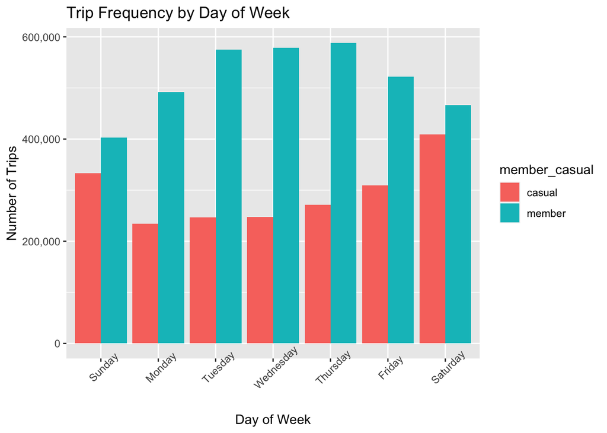

```r
# plotting bar chart
ggplot(daily_trips) + geom_bar(mapping = aes(x = day_of_week, y = average_trip_count, fill = member_casual), stat = "identity", position = position_dodge()) +
labs(title = "Trip Frequency by Day of Week",
  x = "Day of Week",
  y = "Number of Trips",) +
theme(axis.text.x = element_text(angle = 45)) +
scale_y_continuous(labels = label_comma())
```

```r
DT::datatable(daily_trips) #opens up a table to the data
```

|  | day_of_week | member_casual | average_trip_count |
| --- | --- | --- | --- |
| 1 | Sunday | casual | 333569 |
| 2 | Sunday | member | 402599 |
| 3 | Monday | casual | 234711 |
| 4 | Monday | member | 491858 |
| 5 | Tuesday | casual | 246815 |
| 6 | Tuesday | member | 575390 |
| 7 | Wednesday | casual | 247859 |
| 8 | Wednesday | member | 578829 |
| 9 | Thursday | casual | 271144 |
| 10 | Thursday | member | 588141 |

[output cut: 4 more lines]

### Popular Routes and Stations Data

Understanding the differences between members who are casual vs annual can be done through the pattern of destination. Annual members are likely to have common destinations, whilst casual members may have specified destinations that garner casual use. Here we look to confirm our assumptions.

#### Creating a chart on Station Frequency

A new dataframe is made specific to stations, so that custom aggregations for MoM (month over month) data can be explored.

```r
#this will allow us to get start counts on a monthly basis per each Assuming 'clean_df' is your original data frame
station_df <- clean_df %>%
  filter(!is.na(start_station_name)) %>%
  mutate(
    # Replace "%m/%d/%Y" with the actual format of start_date in your data
    year_month = format(as.Date(start_date, format = "%m/%d/%Y"), "%Y-%m"),
    # Ensure start_time is in the correct format for conversion
    start_time = format(as.POSIXct(start_time, format = "%H:%M:%S"), "%H:%M:%S")
  )

station_df <- station_df %>%
  select(ride_id,started_at,start_station_name,end_station_name,member_casual,ride_length,start_date,year_month,rideable_type)
```

```r
#finding top 10 stations. Given the large list and various kinds
station_counts <- station_df %>%
  group_by(start_station_name, member_casual, year_month, rideable_type) %>%
  summarize(count = n(), .groups = "drop")

top_start_stations <- station_counts %>%
  group_by(member_casual, year_month) %>%
  slice_max(n = 5, order_by = count)
```

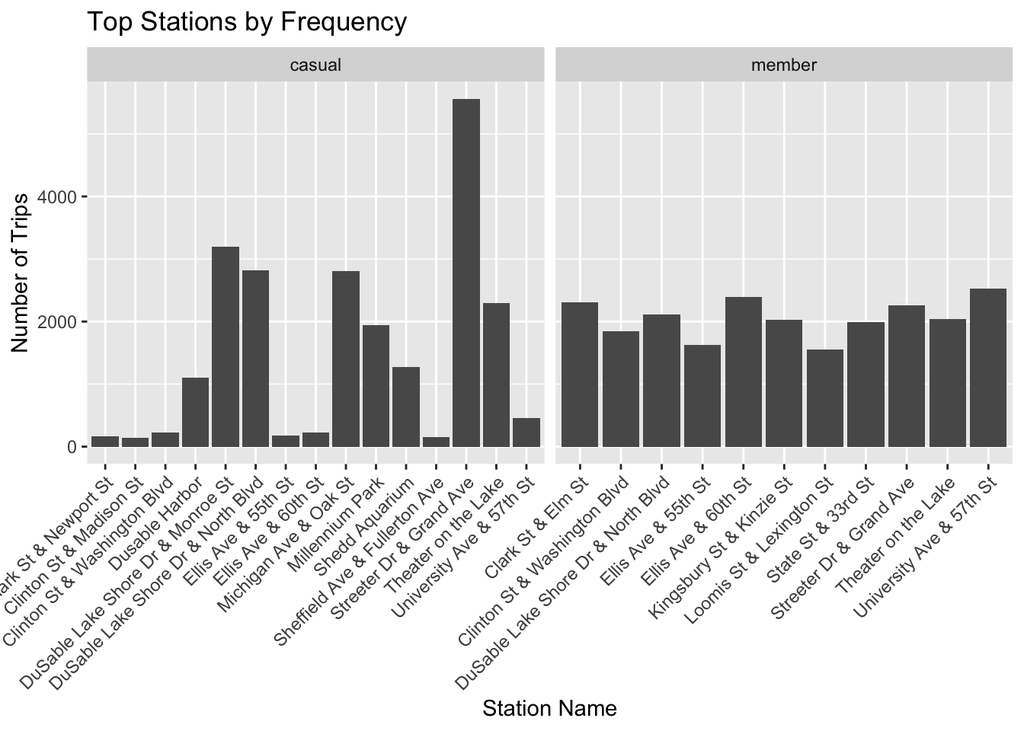

```r
ggplot(top_start_stations) +
  geom_bar(aes(x = start_station_name, y = count), stat = "identity", position = position_dodge()) +
  labs(title = "Top Stations by Frequency",
    x = "Station Name",
    y = "Number of Trips") +
  facet_wrap(~ member_casual, scales = "free_x") +
  theme(axis.text.x = element_text(angle = 45, hjust = 1))
```

```r
# View the data afterwards for supplementary information
DT::datatable(top_start_stations)
```

|  | start_station_name | member_casual | year_month | rideable_type | count |
| --- | --- | --- | --- | --- | --- |
| 1 | Shedd Aquarium | casual | 2022-12 | classic_bike | 182 |
| 2 | DuSable Lake Shore Dr &amp; Monroe St | casual | 2022-12 | classic_bike | 173 |
| 3 | Clark St &amp; Newport St | casual | 2022-12 | electric_bike | 171 |
| 4 | Shedd Aquarium | casual | 2022-12 | electric_bike | 171 |
| 5 | Streeter Dr &amp; Grand Ave | casual | 2022-12 | classic_bike | 169 |
| 6 | Ellis Ave &amp; 60th St | casual | 2023-01 | classic_bike | 229 |
| 7 | University Ave &amp; 57th St | casual | 2023-01 | classic_bike | 202 |
| 8 | Ellis Ave &amp; 55th St | casual | 2023-01 | classic_bike | 163 |
| 9 | Sheffield Ave &amp; Fullerton Ave | casual | 2023-01 | electric_bike | 151 |
| 10 | Clinton St &amp; Madison St | casual | 2023-01 | electric_bike | 142 |

[output cut: 110 more lines]

The following insights were found: * There is a concentration of trips among casual riders at specific stations, which are likely points of interest or recreational destinations. * Member trips are more evenly spread out across stations, aligning with the varied starting or ending points expected of regular commutes.